# nhs_cancer

jane_hogg

2022-11-28

### Purpose of the Data Review

In order to inform current and future planning for provision of cancer treatment services in NHS Borders, you would like to gain a better understanding of the incidence of cancer in NHS Borders.

For example if there is a higher than average type of cancer detected in the Borders, or disparity in the number of cancer patients by gender then resources may need to be allocated in a different way or preventative screening activity increased.

###Overview of Trends in Cancer in NHS Borders

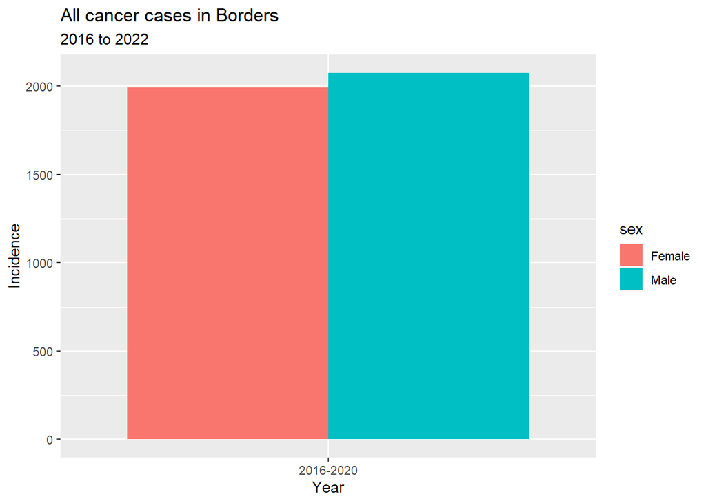

[figure not shown]

[figure not shown]

1 Basal cell carcinoma of the skin 2 Breast 3 Colon 4 Colorectal cancer 5 Malignant melanoma of the skin 6 Non-Hodgkin lymphoma 7 Non-melanoma skin cancer 8 Rectum and rectosigmoid junction 9 Squamous cell carcinoma of the skin 10 Trachea, bronchus and lung

## Comparing the Border to other local authorities

Borders is geographically spread, rural and with a smaller population in relation to a numbe of other place in Scotland. Employment is heavily focused on farming. Comparative analysis across all local authorizes (in particular cities with a higher population) may not be that helpful and so my analysis has focused on a comparable area - Dumfries & Galloway.

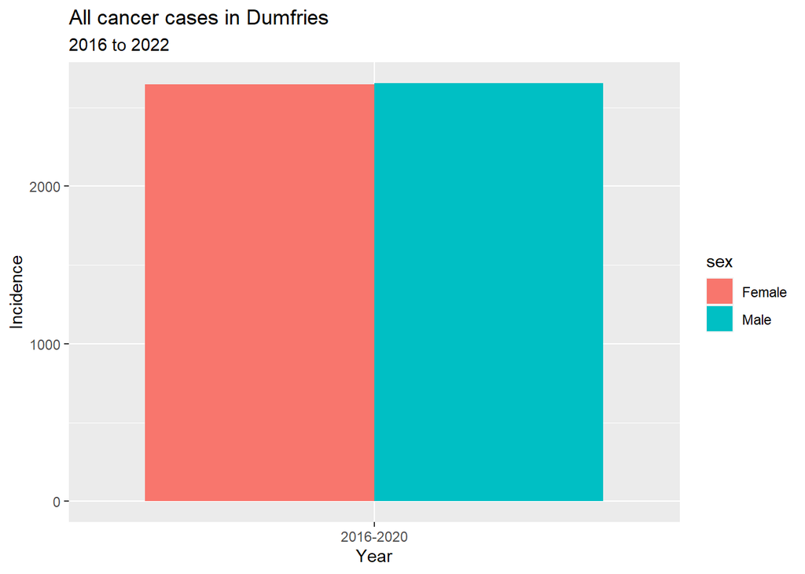

##Interesting that this would suggest that there is little difference between genders in Dumfries.

1 Basal cell carcinoma of the skin 2 Breast 3 Colon 4 Colorectal cancer 5 Head and neck 6 Non-Hodgkin lymphoma 7 Non-melanoma skin cancer 8 Rectum and rectosigmoid junction 9 Squamous cell carcinoma of the skin 10 Trachea, bronchus and lung

There is limited difference in the top 10 types of cancer other than in Dumfries the incidence of Head and Neck related cancer appears in the data.